# **Assignment - 2**

## 1. Introduction

As fossil fuel reserves continue to decline, the direct production of dimethyl ether (DME) from carbon dioxide and hydrogen has attracted growing attention from both the scientific community and industry. DME functions not merely as a valuable chemical intermediate, but also stands out as an attractive option for blending with or replacing traditional liquid fuels like diesel. Its physicochemical characteristics and combustion behavior including a cetane rating of 55 and reduced emissions of nitrogen oxides, sulfur oxides, and carbon monoxide make it a compelling environmentally-friendly fuel alternative.[1–7]

That said, DME's extremely low boiling point (−24.8°C) represents a significant drawback when compared to synthetic fuels generated through Fischer–Tropsch processes, as this property demands considerable changes to current fuel distribution and storage systems.[1] Moreover, should atmospheric CO₂ capture prove economically viable at industrial levels, this production route could simultaneously help combat climate change while supplying a renewable carbon feedstock that does not rely on limited fossil resources. Consequently, worldwide DME output presently standing at roughly 5–7 million tons each year is projected to expand in the foreseeable future.[1]

### 1.1 Reaction Scheme

The following reaction scheme occurs on a bifunctional catalyst, with methanol (MeOH) acting as an intermediate compound:[3]

Direct CO₂ hydrogenation to methanol: $$\text{CO}_2 + 3\text{H}_2 \rightleftharpoons \text{CH}_3\text{OH} + \text{H}_2\text{O} \quad \Delta\text{H}_{\text{R},298\text{K}} = -49.4\,\text{kJ}\,\text{mol}^{-1} \tag{1}$$ CO hydrogenation to methanol: $$\text{CO} + 2\text{H}_2 \rightleftharpoons \text{CH}_3\text{OH} \quad \Delta\text{H}_{\text{R},298\text{K}} = -90.6\,\text{kJ}\,\text{mol}^{-1} \tag{2}$$ Reverse water-gas shift (RWGS): $$\text{CO}_2 + \text{H}_2 \rightleftharpoons \text{CO} + \text{H}_2\text{O} \quad \Delta\text{H}_{\text{R},298\text{K}} = 41.2\,\text{kJ}\,\text{mol}^{-1} \tag{3}$$ Methanol dehydration to DME: $$2\text{CH}_3\text{OH} \rightleftharpoons \text{CH}_3\text{OCH}_3 + \text{H}_2\text{O} \quad \Delta\text{H}_{\text{R},298\text{K}} = -23.4\,\text{kJ}\,\text{mol}^{-1} \tag{4}$$

### 1.2 Thermodynamic Insights

Reaction (1) depicts the straightforward hydrogenation of CO₂ to methanol, releasing heat in an exothermic process. Thermodynamically, this favors elevated temperatures and reduced pressures to maximize CO₂ conversion. Alternatively, methanol can be generated through an indirect pathway involving the reverse water-gas shift (RWGS) reaction shown in Eq. (3), with subsequent hydrogenation of the CO produced following Eq. (2).

While the RWGS reaction absorbs heat (endothermic) without altering the mole count, methanol formation is highly exothermic and reduces the overall number of molecules. These contrasting thermodynamic characteristics create opposing temperature and pressure dependencies, limiting conversion according to equilibrium constraints.

The overall yield benefits from the dehydration of methanol to DME described in Eq. (4), which drives the equilibrium forward by continuously consuming methanol. This dehydration reaction is also exothermic.[1]

### 1.3 Industrial Operating Conditions

Industrial operation of this process generally employs:

- Pressure range: 3–7 MPa
- Temperature range: 240–280°C
- Catalyst type: Copper-based catalysts dispersed on metal oxide supports (e.g.,ZnO and Al₂O₃)[3]

Incorporating a water-conducting membrane presents an attractive avenue for process enhancement; however, maintaining membrane integrity under the harsh conditions needed for DME production poses a significant technical hurdle.[3,4]

The present study models this process for a facility targeting an annual DME output of 1000 tonnes. Initially, the equilibrium DME yield is determined as a function of temperature, pressure, and feed composition, since equilibrium represents the theoretical maximum achievable under specified reaction conditions.

## 2. Method

$$\text{CO}_2 = F_r \text{H}_2 \tag{5}$$

Starting from a target annual DME production of 1000 tonnes, we estimate the total inlet molar flow rate, denoted $\dot{n}_{in,total}$. For our initial calculation, we assume a DME yield of 40% together with a ratio factor of 1. Under continuous operation, this translates to a required feed rate of roughly 6.0 mol s⁻¹ of CO₂ and H₂ entering the reactor.

Whenever the feed composition is varied, the total inlet molar flow rate is held constant. The individual flow rates of CO₂ and H₂, expressed as functions of the ratio factor, are then given by Eq. (6) and Eq. (7), respectively.

$$\dot{n}_{\text{CO}_2} = \frac{1}{1 + \frac{1}{F_r}} \, \dot{n}_{\text{in,total}} \tag{6}$$

$$\dot{n}_{\text{H}_2} = \frac{1}{1 + F_r} \, \dot{n}_{\text{in,total}} \tag{7}$$

```python
import numpy as np
import matplotlib.pyplot as plt
from scipy.optimize import root, minimize
import pandas as pd # For organizing thermodynamic dat
from numpy.linalg import matrix_rank # Added import for matrix_rank
# define vectors for typical ranges of T, p and ratio factor
T = np.linspace(200+273, 300+273, 70) # temperature in K
p = np.array([30, 50, 70]) # total pressure in bar
ratio_dinom= np.linspace(2,30,29)#gives the X of CO2:H2 is 1:X
ratio=1/ratio_dinom #ratio factor
print(ratio_dinom)
# The total inlet molar flow is kept konstant
n_in_total = 6.0 #total inlet molar flow in mol/s
# the inlet molar flow for different ratio factor
n_in=np.empty([ratio.shape[0],6]) # generate empty matrix of required size

for rr in range(ratio.shape[0]):
    n_in[rr,:]= np.array([n_in_total/(1+(1/ratio[rr])), 0, 0, n_in_total*(1/(ratio[rr]+1)), 0, 0]) #inlet molar flow of CO2, CO, DME, H2, H2O, MeOH in mol/s
```

```
[ 2.  3.  4.  5.  6.  7.  8.  9. 10. 11. 12. 13. 14. 15. 16. 17. 18. 19.
 20. 21. 22. 23. 24. 25. 26. 27. 28. 29. 30.]
```

### 2.1 Equilibrium and Composition Modeling

The equilibrium coefficient, $K_{x,j}$, is a reaction-dependent parameter governed by the system's temperature and pressure. Upon reaching equilibrium, the mixture achieves a specific composition, $\underline{x}$, which must satisfy the equilibrium requirements for every reaction $j$ taking place in the system. These conditions are defined as follows:

$$K_{x,1} = \frac{x_{\text{MeOH}} \, x_{\text{H}_2\text{O}}}{x_{\text{CO}_2} \, x_{\text{H}_2}^3} \tag{8}$$

$$K_{x,2} = \frac{x_{\text{MeOH}}}{x_{\text{CO}} \, x_{\text{H}_2}^2} \tag{9}$$

$$K_{x,3} = \frac{x_{\text{CO}} \, x_{\text{H}_2\text{O}}}{x_{\text{CO}_2} \, x_{\text{H}_2}} \tag{10}$$

$$K_{x,4} = \frac{x_{\text{DME}} \, x_{\text{H}_2\text{O}}}{x_{\text{MeOH}}^2} \tag{11}$$

This framework generates a system of four equations containing five unknown mole fractions; however, the composition of the sixth component can be expressed in terms of the others. By utilizing the **reaction extent** ($\xi$), the composition of all components can be simplified and expressed using only four independent variables. The general form of this relationship is shown in **Equation (12)**, where $\nu_{i,j}$ signifies the stoichiometric coefficient of component $i$ within reaction $j$:

$$x_{i,\text{out}} = \frac{\dot{n}_{i,\text{out}}}{\dot{n}_{\text{out}}} = \frac{\dot{n}_{\text{in}} + \sum_j \xi_j \nu_{i,j}}{\dot{n}_{\text{in}} - \sum_j \xi_j \sum_i \nu_{i,j}} \tag{12}$$

### 2.2 Stoichiometric Matrix Analysis

By analyzing the rank of the stoichiometric coefficient matrix $\underline{N}$, the number of independent reactions and key components can be identified. This allows for a significant reduction in the complexity of the governing equations.

The stoichiometric coefficient matrix $\underline{N}$ is defined as:

$$ \underline{N} = \begin{array}{r} \text{CO}_2 \\ \text{CO} \\ \text{H}_2 \\ \text{H}_2\text{O} \\ \text{CH}_3\text{OH} \\ \text{CH}_3\text{OCH}_3 \end{array} \begin{array}{c} \begin{array}{cccc} R_1 & R_2 & R_3 & R_4 \end{array} \\ \left[ \begin{array}{rrrr} -1 & 0 & -1 & 0 \\ 0 & -1 & 1 & 0 \\ -3 & -2 & -1 & 0 \\ 1 & 0 & 1 & 1 \\ 1 & 1 & 0 & -2 \\ 0 & 0 & 0 & 1 \end{array} \right] \end{array} \tag{13} $$

```python
# Defining the matrix of stoichiometric coefficients (N)
# Components (rows): CO2, CO, H2, CH3OH, CH3OCH3, H2O
# Reactions (cols): R1, R2, R3, R4
N_stoich = np.array([
    [-1,  0, -1,  0],  # CO2
    [ 0, -1,  1,  0],  # CO
    [-3, -2, -1,  0],  # H2
    [ 1,  1,  0, -2],  # CH3OH
    [ 0,  0,  0,  1],  # CH3OCH3 (DME)
    [ 1,  0,  1,  1]   # H2O
])
# Determination of the rank of the matrix
N_stoich_rank = matrix_rank(N_stoich)
print(r'Rank of reactions:',N_stoich_rank) #display of matrixrank
```

```
Rank of reactions: 3
```

**2.3 Independent Reaction Selection**

The stoichiometric analysis indicates that three independent reactions and three key components are sufficient to describe the reaction extents. By selecting reactions Eq. (1), Eq. (3), and Eq. (4),together with the components CO<sub>2</sub>, CO, and MeOH, the corresponding submatrix $\underline{N}_{11}$ is obtained. The rank of the submatrix $\underline{N}_{11}$ is likewise equal to 3, thereby confirming the validity of this selection. Consequently, rearrangement of the stoichiometric coefficient matrix yields the following matrix $\underline{N}_{new}$

```python
#new matrix of stoichiometric coefficients
N_stoich_new=np.array([[-1, -1,  0,  0],  #CO2
                       [ 0,  1,  0, -1],  #CO
                       [ 1,  0, -2,  1],  #CH3OH
                       [-3, -1,  0, -2],  #H2
                       [ 1,  1,  1,  0],  #H2O
                       [ 0,  0,  1,  0]]) #CH3OCH3
```

# **3. Reaction Analysis**

### 3.1 Thermodynamic properties

To evaluate the thermodynamics of the reaction system, temperature-dependent properties such as heat capacity ($C_p$), entropy ($S$), and enthalpy ($H$) were first computed using Glenn equations from the NASA database [9] and then compared with computed values from Shomate equations from the NIST database [8].

$$\frac{C_p^0(T)}{R} = a_1 T^{-2} + a_2 T^{-1} + a_3 + a_4 T^1 + a_5 T^2 + a_6 T^3 + a_7 T^4 \tag{14}$$

$$\frac{H^0(T)}{RT} = -a_1 T^{-2} + \frac{a_2 \ln(T)}{T} + a_3 + \frac{a_4 T^1}{2} + \frac{a_5 T^2}{3} + \frac{a_6 T^3}{4} + \frac{a_7 T^4}{5} + \frac{b_1}{T} \tag{15}$$

$$\frac{S^0(T)}{R} = \frac{-a_1 T^{-2}}{2} - a_2 T^{-1} + a_3 \ln(T) + a_4 T + \frac{a_5 T^2}{2} + \frac{a_6 T^3}{3} + \frac{a_7 T^4}{4} + b_2 \tag{16}$$

### 3.2 Thermodynamic Properties (Shomate Equations)

Thermodynamic properties are implemented in Python using the Shomate equations:

$$c_p = A + B\vartheta + C\vartheta^2 + D\vartheta^3 + E\vartheta^{-2} \tag{17}$$

$$H - H(298.15\,\text{K}) = A\vartheta + \frac{B\vartheta^2}{2} + \frac{C\vartheta^3}{3} + \frac{D\vartheta^4}{4} - E\vartheta^{-1} + F - H \tag{18}$$

$$S = A\ln(\vartheta) + B\vartheta + \frac{C\vartheta^2}{2} + \frac{D\vartheta^3}{3} - \frac{E\vartheta^{-2}}{2} + G \tag{19}$$

```python
import numpy as np

def get_thermo_data(T, comp):
    """
    Returns [Cp (J/mol K), H (kJ/mol), S (kJ/mol K)]
    """
    T_val = T
    t_shomate = T / 1000

    # 1. Shomate Model (CO2, CO, H2, H2O)
    if comp in ['CO2', 'CO', 'H2', 'H2O']:
        # Parameters (H is in kJ/mol, S is in J/mol K)
        params = {
            'CO2': [24.99735, 55.18696, -33.69137, 7.948387, -0.136638, -403.6075, 228.2431, -393.5224],
            'CO':  [25.56759, 6.096130, 4.054656, -2.671301, 0.131021, -118.0089, 227.3665, -110.5271],
            'H2':  [33.066178, -11.363417, 11.432816, -2.772874, -0.158558, -9.980797, 172.707974, 0.0],
            'H2O': [30.09200, 6.832514, 6.793435, -2.534480, 0.082139, -250.8810, 223.3967, -241.8264]
        }
        p = np.array(params[comp])
        cp_vec = np.array([1, t_shomate, t_shomate**2, t_shomate**3, t_shomate**-2, 0, 0, 0])
        h_vec  = np.array([t_shomate, t_shomate**2/2, t_shomate**3/3, t_shomate**4/4, -t_shomate**-1, 1, 0, -1])
        s_vec  = np.array([np.log(t_shomate), t_shomate, t_shomate**2/2, t_shomate**3/3, -t_shomate**-2/2, 0, 1, 0])

        cp = cp_vec.dot(p)
        h = p[-1] + h_vec.dot(p) # NIST Shomate H is already in kJ/mol
        s = s_vec.dot(p) / 1000  # Convert J/mol K to kJ/mol K
        return np.array([cp, h, s])

    # 2. NASA Model (DME, MeOH)
    elif comp in ['DME', 'CH3OH']:
        R = 8.3143
        params = {
            'DME':  ([ -2.693103242*10**5, 4.300709710*10**3, -21.52788028, 8.131833390*10**-2, -8.295671320*10**-5, 4.801911510*10**-8, -1.188699808*10**-11, -4.410237090*10**4, 1.467666934*10**2]),
            'CH3OH': ([ -2.416642886*10**5, 4.032147190*10**3, -20.46415436, 6.903698070*10**-2, -7.598932690*10**-5, 4.598208360*10**-8, -1.158706744*10**-11, -4.433261170*10**4, 1.400142190*10**2])
        }
        p = np.array(params[comp])
        cp_vec = np.array([T_val**-2, T_val**-1, 1, T_val, T_val**2, T_val**3, T_val**4, 0, 0])
        h_vec  = np.array([-T_val**-1, np.log(T_val), T_val, T_val**2/2, T_val**3/3, T_val**4/4, T_val**5/5, 1, 0])
        s_vec  = np.array([-T_val**-2/2, -T_val**-1, np.log(T_val), T_val, T_val**2/2, T_val**3/3, T_val**4/4, 0, 1])

        cp = cp_vec.dot(p) * R
        h = (h_vec.dot(p) * R) / 1000 # Convert J/mol to kJ/mol
        s = (s_vec.dot(p) * R) / 1000 # Convert J/mol K to kJ/mol K
        return np.array([cp, h, s])

# Execution
T = 298.15 # 25+273.15
comps = ['CO2', 'CO', 'H2', 'H2O', 'DME', 'CH3OH']

print('vector of standard enthalpy in kJ/mol and entropy in kJ/mol K')
for c in comps:
    res = get_thermo_data(T, c)
    print(f'for {c}: [{res[1]:.5e}   {res[2]:.8f}]')
```

```
vector of standard enthalpy in kJ/mol and entropy in kJ/mol K
for CO2: [-3.93525e+02   0.21378763]
for CO: [-1.10524e+02   0.19766288]
for H2: [1.49248e-04   0.13068015]
for H2O: [-2.41826e+02   0.18883527]
for DME: [-1.84105e+02   0.26737381]
for CH3OH: [-2.00935e+02   0.23980407]
```

Before calculating the equilibrium coefficient the thermodynamic properties at standard conditions are validated by the literature data in table 1.

Table 1: The standard enthalpy and entropy that is estimated are validated by literature data. [8,10]

[output not shown]

```python
def rxn_data(T):
    res = np.empty([3,5]) # generate empty vector of required size
    # call the function on thermodynamic properties for all components
    data_CO2 = components['CO2'].calculate(T)
    data_CO = components['CO'].calculate(T)
    data_H2 = components['H2'].calculate(T)
    data_H2O = components['H2O'].calculate(T)
    data_CH3OH = components['CH3OH'].calculate(T)
    data_CH3OCH3 = components['DME'].calculate(T)

    # use stoichiometry to calculate the thermodynamic properties of reaction 1
    res[0,0] = data_CH3OH[0] + data_H2O[0] - data_CO2[0] - 3*data_H2[0] # reaction heat capacity in J/mol K
    res[0,1] = data_CH3OH[1] + data_H2O[1] - data_CO2[1] - 3*data_H2[1] # reaction enthalpy in J/mol
    res[0,2] = data_CH3OH[2] + data_H2O[2] - data_CO2[2] - 3*data_H2[2] # reaction entropy in J/mol K
    res[0,3] = res[0,1] - T*res[0,2] # reaction Gibbs enthalpy in J/mol
    res[0,4] = np.exp(-res[0,3]/(8.3145*T)) # reaction equilibrium constant

    # use stoichiometry to calculate the thermodynamic properties of reaction 3
    res[1,0] = data_CO[0] + data_H2O[0] - data_CO2[0] - data_H2[0] # reaction heat capacity in J/mol K
    res[1,1] = data_CO[1] + data_H2O[1] - data_CO2[1] - data_H2[1] # reaction enthalpy in J/mol
    res[1,2] = data_CO[2] + data_H2O[2] - data_CO2[2] - data_H2[2] # reaction entropy in J/mol K
    res[1,3] = res[1,1] - T*res[1,2] # reaction Gibbs enthalpy in J/mol
    res[1,4] = np.exp(-res[1,3]/(8.3145*T)) # reaction equilibrium constant

    # use stoichiometry to calculate the thermodynamic properties of reaction 4
    res[2,0] = data_CH3OCH3[0] + data_H2O[0] - 2*data_CH3OH[0]  # reaction heat capacity in J/mol K
    res[2,1] = data_CH3OCH3[1] + data_H2O[1] - 2*data_CH3OH[1]  # reaction enthalpy in J/mol
    res[2,2] = data_CH3OCH3[2] + data_H2O[2] - 2*data_CH3OH[2]  # reaction entropy in J/mol K
    res[2,3] = res[2,1] - T*res[2,2] # reaction Gibbs enthalpy in J/mol
    res[2,4] = np.exp(-res[2,3]/(8.3145*T)) # reaction equilibrium constant

    return res

print('vector of reaction enthalpy in kJ/mol Gibbs free reaction enthalpy in kJ/mol K')
print('of the reaction 1:', rxn_data (25+273.15)[0,[1,3]]/1000) # display key result for check
print('of the reaction 3:', rxn_data (25+273.15)[1,[1,3]]/1000) # display key result for check
print('of the reaction 4:', rxn_data (25+273.15)[2,[1,3]]/1000) # display key result for check

# Restore T to be the temperature range array from Rq3vZHGlEfG0, as it was overwritten by a scalar T in a preceding cell.
T = np.linspace(200+273, 300+273, 70)

K_x = np.empty([p.shape[0],T.shape[0],3]) # generate empty vector of required size

# The previous `for rxn in range(2):` loop was redundant as the assignments within
# its body were fixed for indices 0, 1, and 2 and were not dependent on `rxn`.
# These assignments would have been repeated twice.
for TT in range(T.shape[0]): # vary the temperature within the given range

    # at each single temperature
    rxn_data_get = rxn_data(T[TT]) # call the function for thermodynamic data of the reaction
    K_eq = rxn_data_get[:,-1] # the last element in the results vector provides the thermodynamic equilibrium constant
    K_x[:,TT,0] = K_eq[0]*np.power(p,2) # calculate K_x at each temperature for all pressures for reaction 1
    K_x[:,TT,1] =  K_eq[1]*np.power(p,0) # calculate K_x at each temperature for all pressures for reaction 3
    K_x[:,TT,2] = K_eq[2]*np.power(p,0) # calculate K_x at each temperature for all pressures for reaction 4
```

```
vector of reaction enthalpy in kJ/mol Gibbs free reaction enthalpy in kJ/mol K
of the reaction 1: [-49.25439763   3.61218799]
of the reaction 3: [41.17414002 28.64395745]
of the reaction 4: [-24.03973165 -17.12590709]
```

The reaction enthalpy and Gibbs free reaction enthalpy at 25 °C are as well validated by the literature in table 2. Therefore all thermodynamic properties are checked, which are needed to calculate the thermodynamic reaction equilibrium constant, and therfore these values are directly validated as well.

Table 2: The reaction enthalpy and Gibbs free reaction enthalpy at 25 °C are validated by literature data. [3]

[output not shown]

```python
import numpy as np
def calculate_reaction_extents(xi, n_in, T, p, ratio):
    """
    Solves the non-linear system for reaction extents.
    xi: array of extents [xi1, xi2, xi3]
    """
    # 1. Get current composition and thermodynamic constants
    x = composition(xi, n_in) # Assumed defined elsewhere
    rxn_data_get = rxn_data(T)
    k_eq = rxn_data_get[:, -1]

    # 2. Map indices to readable names (example mapping based on your previous code)
    # x = [CO2, CO, CH3OH, H2, H2O, DME]
    comp = {
        'CO2': x[0], 'CO': x[1], 'CH3OH': x[2],
        'H2': x[3], 'H2O': x[4], 'DME': x[5]
    }
        # 3. Define the equilibrium expressions
    # Form: K_eq * (Reactants) - (Products) = 0
    # Rxn 1: CO2 + 3H2 <-> CH3OH + H2O
    r1 = k_eq[0] * (p**2) * (comp['CO2'] * comp['H2']**3) - (comp['CH3OH'] * comp['H2O'])

    # Rxn 3: CO2 + H2 <-> CO + H2O
    r3 = k_eq[1] * (p**0) * (comp['CO2'] * comp['H2']) - (comp['CO'] * comp['H2O'])

    # Rxn 4: 2CH3OH <-> DME + H2O
    r4 = k_eq[2] * (p**0) * (comp['CH3OH']**2) - (comp['DME'] * comp['H2O'])

    return np.array([r1, r3, r4])
```

**3.3 Determination of Equillibrium yield and conversion**

With the reaction equilibrium coefficient, all the information needed to solve the set of equations is provided. For each combination of temperature, pressure and inlet composition a solvent vector is obtained, which consists of the reaction extent of the three key reactions. These are used to determine the equilibrium composition, which can then be used to estimate the DME yield with respect to $CO_2$ $Y_{DME,CO_2}$ and the $CO_2$ conversion $U_{CO_2}$ with the help of Eq. (19) and (20). [6]

$$Y_{DME,CO_2} = \frac{\sum_j \nu_{CO_2,j}}{\sum_j \nu_{DME,j}} \frac{\dot{n}_{DME,in} - \dot{n}_{DME}}{\dot{n}_{CO_2,in}} \quad (20)$$

$$U_{CO_2} = \frac{\dot{n}_{CO_2,in} - \dot{n}_{CO_2}}{\dot{n}_{CO_2,in}} \quad (21)$$

```python
import numpy as np
from itertools import product
from scipy.optimize import root

def run_simulation(pressures, temperatures, ratios, n_in_array):
    """
    Executes the equilibrium simulation over a grid of P, T, and Ratios.
    """
    # Initialize output structures
    shape = (len(pressures), len(temperatures), len(ratios))
    xi = np.zeros((*shape, 3))
    x_out = np.zeros((*shape, 6))

    xi_guess = np.array([0.35, 0.02, 0.15])

    # Using itertools.product to replace nested loops
    for i, (pp, TT, rr) in enumerate(product(range(len(pressures)),
                                            range(len(temperatures)),
                                            range(len(ratios)))):
        # Solver call
        args = (n_in_array[rr], temperatures[TT], pressures[pp], ratios[rr])
        res = root(rxn_ext, xi_guess, args=args, method='lm')

        # Check for successful convergence before assigning results
        if res.success:
            xi[pp, TT, rr] = res.x
            x_out[pp, TT, rr] = composition(res.x, n_in_array[rr])
        else:
            # Assign NaN to indicate non-convergence
            xi[pp, TT, rr] = np.nan
            x_out[pp, TT, rr] = np.nan * np.ones(6) # Assuming 6 components

    # Vectorized Post-Processing
    # n_in_sum_per_ratio: total inlet molar flow for each ratio (shape: (len(ratios),))
    n_in_sum_per_ratio = np.sum(n_in_array, axis=1)

    # Broadcast n_in_sum_per_ratio to (1, 1, len(ratios), 1) to align with xi and x_out
    n_in_sum_broadcast = n_in_sum_per_ratio[np.newaxis, np.newaxis, :, np.newaxis]

    # n_out calculation: x_out * (total_inlet_moles - 2 * extent_of_reaction_1)
    # The term (n_in_sum_broadcast - 2 * xi[..., 0:1]) broadcasts to (len(p), len(T), len(ratio), 1)
    # n_out will have shape (len(p), len(T), len(ratio), num_components)
    n_out = x_out * (n_in_sum_broadcast - 2 * xi[..., 0:1])

    # Y calculation (Conversion of Methanol, based on CO2 feed and MeOH outlet)
    # n_in_MeOH: Methanol inlet flow (n_in_array[:, 5], which is 0 for this problem setup)
    n_in_MeOH = n_in_array[:, 5] # Shape (len(ratios),)
    n_in_MeOH_broadcast = n_in_MeOH[np.newaxis, np.newaxis, :, np.newaxis] # Shape (1, 1, len(ratios), 1)
    n_out_MeOH_broadcast = n_out[..., 5][:, :, :, np.newaxis] # Shape (len(p), len(T), len(ratios), 1)

    # n_in_CO2: CO2 inlet flow (n_in_array[:, 0])
    n_in_CO2 = n_in_array[:, 0] # Shape (len(ratios),)
    n_in_CO2_broadcast = n_in_CO2[np.newaxis, np.newaxis, :, np.newaxis] # Shape (1, 1, len(ratios), 1)

    # Y will have shape (len(p), len(T), len(ratios), 1) after broadcasting
    Y = ((-2/1) * (n_in_MeOH_broadcast - n_out_MeOH_broadcast)) / n_in_CO2_broadcast

    # U calculation (Conversion of CO2)
    n_out_CO2_broadcast = n_out[..., 0][:, :, :, np.newaxis] # Shape (len(p), len(T), len(ratios), 1)

    # U will have shape (len(p), len(T), len(ratios), 1) after broadcasting
    U = (n_in_CO2_broadcast - n_out_CO2_broadcast) / n_in_CO2_broadcast

    return xi, x_out, n_out, Y, U
```

# **4.Results and Discussion**

**4.1 Equilibrium Constants**

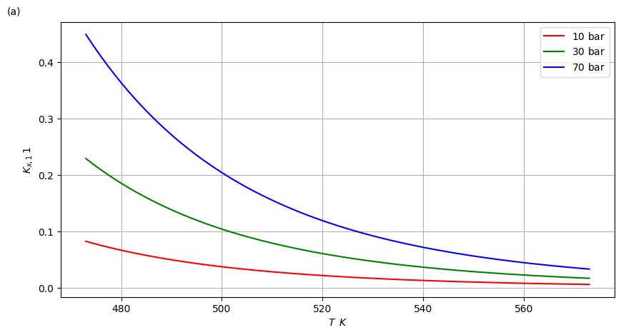

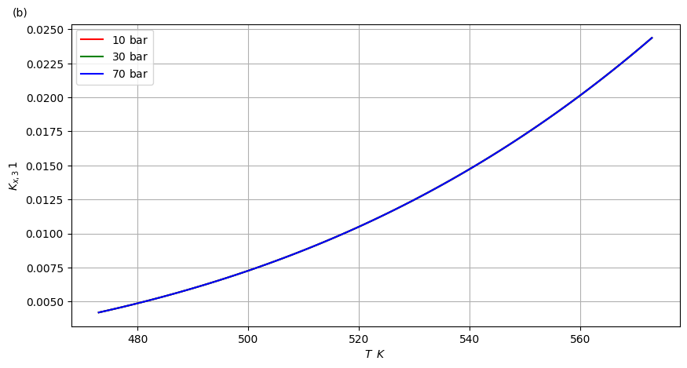

[figure not shown]

```python
import matplotlib.pyplot as plt # import of matplotlibplt.figure(figsize=(10, 5))
plt.grid()
plt.xlabel(r"$T\,\/\,K$")
plt.ylabel(r"$K_{x,1}\,1$")
plt.plot(T[:], K_x[0,:,0], 'r-', label="$10$ bar")
plt.plot(T[:], K_x[1,:,0], 'g-', label="$30$ bar")
plt.plot(T[:], K_x[2,:,0], 'b-', label="$70$ bar")
plt.legend(loc='best')
plt.figtext(0.05,0.9,'(a)')


plt.figure(figsize=(10, 5))
plt.grid()
plt.xlabel(r"$T\,\/\,K$")
plt.ylabel(r"$K_{x,3}\,1$")
plt.plot(T[:], K_x[0,:,1], 'r-', label="$10$ bar")
plt.plot(T[:], K_x[1,:,1], 'g-', label="$30$ bar")
plt.plot(T[:], K_x[2,:,1], 'b-', label="$70$ bar")
plt.legend(loc='best')
plt.figtext(0.05,0.9,'(b)')


plt.figure(figsize=(10, 5))
plt.grid()
plt.xlabel(r"$T\,\/\,K$")
plt.ylabel(r"$K_{x,4}\,1$")
plt.plot(T[:], K_x[0,:,2], 'r-', label="$10$ bar")
plt.plot(T[:], K_x[1,:,2], 'g-', label="$30$ bar")
plt.plot(T[:], K_x[2,:,2], 'b-', label="$70$ bar")
plt.legend(loc='best')
plt.figtext(0.05,0.9,'(c)')
plt.figtext(0.05,0.0,"Figure 1: Reaction equilibrium coefficient v/s temperature at 10, 30 and 70 bar for (a) reaction 1, (b) reaction 3 and (c) reaction 4.")

plt.show()
```

## Analysis of Equilibrium Constants

For reaction (1), the analysis shows a significant increase in the chemical equilibrium constant as pressure rises, particularly at lower temperatures, which is consistent with **Eq. (14)**.

In contrast, the equilibrium constants for the other two reactions are essentially independent of pressure, as the total number of moles is identical on both the reactant and product sides. The impact of temperature is summarized below:

- $ \text{Reactions (1) and (4) are exothermic: the equilibrium constant decreases as temperature increases.} $
- $ \text{Reaction (3) is endothermic: the equilibrium constant increases as the temperature rises.} $

The pressure-dependent behavior of $K_x$ for reaction (1) vs. reactions (3) and (4) highlights the importance of molar volume changes in gas-phase equilibrium.

**4.2 Reaction Extent**

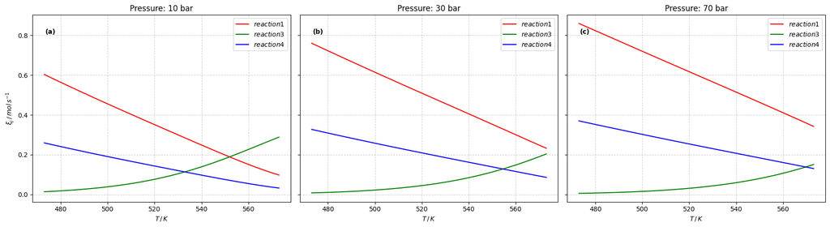

[output not shown]

```python
import matplotlib.pyplot as plt

def plot_reaction_extents(T, xi, p, pressure_labels, ratio_idx=1):
    """
    Creates a 1x3 subplot grid to compare reaction extents across pressures.
    """
    fig, axes = plt.subplots(1, 3, figsize=(18, 5), sharey=True)
    rxn_styles = [('r-', 'reaction 1'), ('g-', 'reaction 3'), ('b-', 'reaction 4')]

    for ax, pp_idx in zip(axes, range(len(p))):
        for rxn_idx, (style, label) in enumerate(rxn_styles):
            ax.plot(T, xi[pp_idx, :, ratio_idx, rxn_idx], style, label=f"${label}$")

        ax.set_title(f"Pressure: {pressure_labels[pp_idx]}")
        ax.set_xlabel(r"$T\,/\,K$")
        ax.grid(True, linestyle='--', alpha=0.6)
        if pp_idx == 0:
            ax.set_ylabel(r"$\xi_j\,/\,mol\,s^{-1}$")
        ax.legend(loc='best')
        ax.text(0.05, 0.9, f"({chr(97+pp_idx)})", transform=ax.transAxes, fontweight='bold')

    plt.tight_layout()
    plt.show()

# Define labels
pressure_labels = ['10 bar', '30 bar', '70 bar']

# Execute Plot
plot_reaction_extents(T, xi, p, pressure_labels)
print("Figure 2: Reaction extent v/s temperature for CO2:H2 ratio of 1:3 at (a) 10 bar, (b) 30 bar and (c) 70 bar.")
```

### Comparison of Reaction Extents

An analysis of the reaction extents for the three key reactions shows that reactions (1) and (4) behave similarly. In both cases, the extent of reaction increases with higher pressure and lower temperature. Since these reactions are exothermic, this temperature dependence is thermodynamically consistent.

For reaction (1), the process results in a reduction of the total number of molecules. According to **Le Chatelier’s principle**, this explains why the reaction extent increases at elevated pressures. Although reaction (4) follows the same trend, the behavior is not directly attributable to a change in the mole count.

In contrast, reaction (3) displays the opposite temperature trend, with the reaction extent increasing at higher temperatures, as expected for an endothermic process. The pressure dependence for reactions (3) and (4) is likely influenced by the coupling of the reaction network:

- $ H_2O \text{ is a product of reactions (1), (3), and (4).} $
- $ \text{MeOH is produced in reaction (1) and consumed in reaction (4).} $

On this basis, the pressure-induced shift towards the reactant side for reaction (3) and the product side for reaction (4) can be rationalized through the interdependence of the reaction network and Le Chatelier’s principle.

**4.3 Equilibrium Yield**

[figure not shown]

```python
# plot yield
plt.figure(figsize=(10, 5))
plt.grid()
plt.xlabel(r"$T\,/\,K$")
plt.ylabel(r"$Y_{DME,CO_2}$ / 1")
plt.figtext(0.25,0.0,'Figure 3: Yield v/s temperature for CO2:H2 ratio of 1:3 at 10, 30 and 70 bar.')
plt.plot(T[:], Y[0,:,1], 'r-', label="$10$ bar")
plt.plot(T[:], Y[1,:,1], 'g-', label="$30$ bar")
plt.plot(T[:], Y[2,:,1], 'b-', label="$70$ bar")
plt.legend(loc='best')
plt.show()
```

### Comparative Analysis of DME Yield

As illustrated in **Figure 3**, the equilibrium yield of DME shows a downward trend as temperature rises and an upward trend as pressure increases. This pattern aligns closely with the reaction extent observed for reaction (4), which is the primary pathway for direct DME production. The correlation between these two results confirms that the model maintains strong internal consistency.

### Literature Comparison

In comparison to existing literature, our findings align reasonably well despite some methodological variances. For instance, **Jia et al. [6]** examined thermodynamic equilibrium under the following conditions:

- $ P = 5 \text{ MPa} $
- $ \text{CO}_2:\text{H}_2 = 1:3 \quad (F_r = 0.33) $

- $ \text{Yield} = 39\% \text{ at } 210 \text{ °C} $
- $ \text{Yield} = 15\% \text{ at } 290 \text{ °C} $

Despite these numerical differences, both studies exhibit the same characteristic behavior: a nearly linear decline in yield that gradually tapers off at elevated temperatures, particularly under low-pressure conditions.

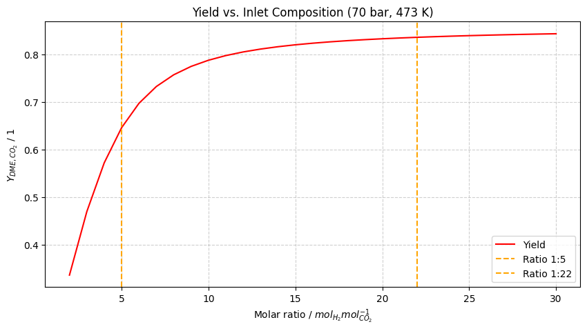

```python
import matplotlib.pyplot as plt
import numpy as np

# --- Plot (a): Yield vs. Inlet Composition ---
plt.figure(figsize=(10, 5))
plt.plot(ratio_dinom, Y[p_plt, T_plt, :], 'r-', label='Yield')
plt.axvline(x=ratio_dinom[ratio1], color='orange', linestyle='--', label=f'Ratio 1:{int(ratio_dinom[ratio1])}')
plt.axvline(x=ratio_dinom[ratio2], color='orange', linestyle='--', label=f'Ratio 1:{int(ratio_dinom[ratio2])}')

plt.xlabel(r"Molar ratio / $mol_{H_2} mol_{CO_2}^{-1}$")
plt.ylabel(r"$Y_{DME,CO_2}$ / 1")
plt.title("Yield vs. Inlet Composition (70 bar, 473 K)")
plt.grid(True, linestyle='--', alpha=0.6)
plt.legend()
plt.show()
```

**4.3 Equilibrium Yield**

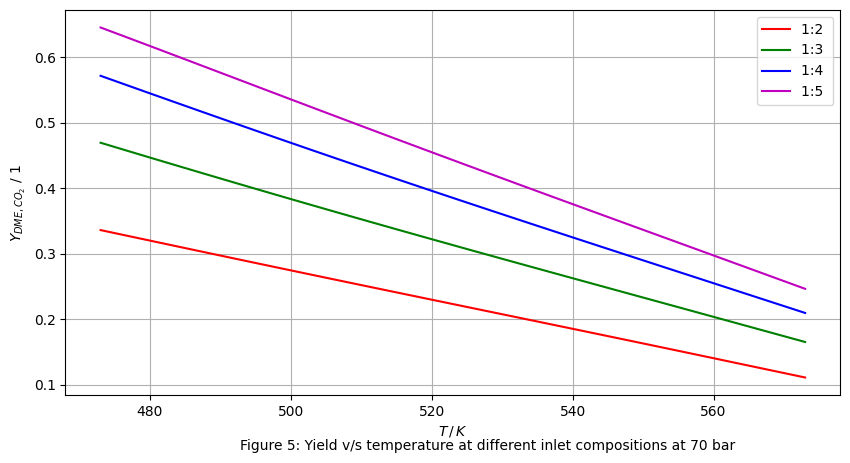

```python
# plot yield
plt.figure(figsize=(10, 5))
plt.grid()
plt.xlabel(r"$T\,/\,K$")
plt.ylabel(r"$Y_{DME,CO_2}$ / 1")
plt.figtext(0.3,0.0,'Figure 5: Yield v/s temperature at different inlet compositions at 70 bar')
plt.plot(T[:], Y[2,:,0], 'r-', label="1:2 ")
plt.plot(T[:], Y[2,:,1], 'g-', label="1:3 ")
plt.plot(T[:], Y[2,:,2], 'b-', label="1:4 ")
plt.plot(T[:], Y[2,:,3], 'm-', label="1:5 ")
plt.legend(loc='best')
plt.show()
```

### Evaluation of Inlet Molar Ratios

Figure 5 illustrates various inlet molar ratios relevant to potential industrial applications, as documented in several experimental investigations [5]. From the data, it is evident that the observed trends remain largely consistent across the different ( \text{CO}_2 : \text{H}_2 ) inlet molar ratios examined.

- $ \text{Observed trends are consistent across different inlet compositions.} $
- $ \text{Industrial applicability is supported by documented experimental ratios [5].} $

[figure not shown]

```python
# plot conversion
plt.figure(figsize=(10, 5))
plt.grid()
plt.xlabel(r"$T\,/\,K$")
plt.ylabel(r"$U_{CO_2}$ / 1")
plt.figtext(0.25,0.0,"Figure 6: Conversion v/s temperature for CO2:H2 ratio of 1:4 at 10, 30 and 70 bar.")
plt.plot(T[:], U[0,:,2], 'r-', label="$10$ bar")
plt.plot(T[:], U[1,:,2], 'g-', label="$30$ bar")
plt.plot(T[:], U[2,:,2], 'b-', label="$70$ bar")
plt.legend(loc='best')
plt.show()
```

### Carbon Dioxide Conversion Analysis

Similar to the results for DME yield, the predicted ($\text{CO}_2 $) conversion in this model is higher than those found in existing literature. A comparison with the study by **Jia et al. [6]** shows:

- $\text{At 480 K: This model (56.5\%) vs. Jia et al. (40\%)}$
- $\text{At 560 K: This model (34\%) vs. Jia et al. (28\%)}$

- $ \text{Reactions (1) and (4) decrease in contribution as temperature rises.} $
- $ \text{Reaction (3) increases in contribution with higher temperatures.} $

# **5. Conclusion**

**Future Outlook:** Membrane-based technologies offer a promising path for the selective removal of $H_2O$, effectively bypassing thermodynamic equilibrium limits. As illustrated by **Van Kampen et al. [4]**, these reactors are a key technology for the sustainable synthesis of DME from ( $\text{CO}_2 ) and ( H_2 $).

# **6. Literature**

- [1] S. Roy, A. Cherevotan, S. C. Peter, *Thermochemical CO2 Hydrogenation to Single Carbon Products: Scientific and Technological Challenges*, ACS Energy Letters 3 (2018) 1938–1966.
- [2] H. Li, S. Ren, S. Zhang, S. Padinjarekutt, B. Sengupta, X. Liang, S. Li, M. Yu, *The high-yield direct synthesis of dimethyl ether from CO2 and H2 in a dry reaction environment*, Journal of Materials Chemistry A 9 (2021) 2678–2682.
- [3] S. Banivaheb, S. Pitter, K. H. Delgado, M. Rubin, J. Sauer, R. Dittmeyer, *Recent Progress in Direct DME Synthesis and Potential of Bifunctional Catalysts*, Chemie Ingenieur Technik 94 (2022) 240–255.
- [4] J. van Kampen, J. Boon, M. van Sint Annaland, *Separation enhanced methanol and dimethyl ether synthesis*, Journal of Materials Chemistry A 9 (2021) 14627–14629.
- [5] M. I. Afokin, M. V. Magomedova, *Process Solutions for Recovery of Dimethyl Ether Produced Through One-Step Synthesis and Their Assessment*, Petroleum Chemistry 61 (2021) 115–122.
- [6] G. Jia, Y. Tan, Y. Han, *A Comparative Study on the Thermodynamics of Dimethyl Ether Synthesis from CO Hydrogenation and CO2 Hydrogenation*, Industrial & Engineering Chemistry Research 45 (2006) 1152–1159.
- [7] Einstufige Dimethylethersynthese, EnArgus, 2023, [Link](https://www.enargus.de/pub/bscw.cgi/d28082/*/*/Einstufige%20Dimethylethersynthese.html?op=Wiki.getwiki), accessed 8 May 2023.
- [8] NIST Chemistry WebBook, [Link](https://webbook.nist.gov/chemistry/), accessed 8 May 2023.
- [9] B. J. McBride, M. J. Zehe, S. Gordon, *NASA Glenn Coefficients for Calculating Thermodynamic Properties of Individual Species*, NASA/TP-2002-211556, 9 January 2002.
- [10] W. M. Haynes, *CRC Handbook of Chemistry and Physics*, 96th ed., CRC Press, 01/2015.

**Contribution: All group members equally contributed to the report.**